# Is it REALLY Giving Diversity?

An exploration of foundation shade variance.

Lindsey Smith

# Introduction

The cosmetic industry is a multibillion dollar worth over 599 Billon USD. Cosmetics can range from a variety of products from nail polish, to face wash and all the beautifying items in between. With such a wide range of products one can’t help but wonder if that diversity in options translates to particular mainstay cosmetic products like foundation.

Focusing on Foundation products, what key pieces of information would answer or at least start to answer the question: Is there variety amongst cosmetic shades? If so, what types of brands seem to have to the most diversity.

# The Data:

I will be using four data sets to explore these features. Below I’ve listed them and the features we will be accessing throughout this data analysis.

- shades.csv
  - shade_id: ID number assigned to each foundation shade
  - product_id: ID number assigned to each product
  - shade_name
- brands.csv
  - brand_id: ID number assigned to each brand
  - brand name: Name of cosmetic brand
- cielab.csv
  - Monk Category : This is a scale from 1-10 to express skintone colors from lightest to darkest.
  - L: Lightness value. This is the percent value from 1-100 of visible luminance to the human eye. AKA: How light/bright something is.
- products.csv
  - brand_id: ID number assigned to each brand
  - product_id: ID number assigned to each product

# It’s Giving Unseasoned:

### Data Cleaning and Feature Enrichment

After seeing the shades dataframe I knew I wanted to add the features skintone,undertone, and specific color code and name (shade name without specific or descriptions).

I used regex and filled and corrected in values that regex couldn’t handle by hand.

```r
shades<- read.csv('shades.csv')
glimpse(shades)
```

```
## Rows: 9,846
## Columns: 4
## $ shade_id   <int> 100000, 100001, 100002, 100003, 100004, 100005, 100006, 100…
## $ product_id <int> 1, 1, 1, 1, 1, 1, 1, 1, 1, 1, 1, 1, 1, 1, 1, 1, 1, 1, 1, 1,…
## $ shade_name <chr> "L2OLIVE", "L2Neutral", "L2PEACH", "LM2OLIVE", "LM1COOL", "…
## $ hex        <chr> "#f2e0b8", "#f0d7ba", "#edccaa", "#e9cfa3", "#f4c9a4", "#ee…
```

I also created mapping for skintone and undertone using to create the new columns.

- Undertone. undertone given in shade_name description i.e(cool, warm, neutral, rosy..etc)”
- Skintone. skintone description given in shade name i.e( dark, rich, fair, medium…etc)
- Shade specific. the color code of a foundation shade
- Name. The shade name of a given foundation product

```r
regex1 <- "^(\\S+)\\s+(?:-\\s+)?(.+)$" # regex to extract the first part of shade name
regex2 <- "^([A-Z0-9]+?)([A-Z][a-z]+|[A-Z]{2,})$" #extracts the second part of shade name

undertone_pattern <- "(?i)(neutral pink| neutral cool|neutral rosy|neutral peach|neutral warm|neutral yellow|
olive|peach|warm|neutral|cool|pink|rosy|yellow|golden|red)" #maapping for undertones

skintone_pattern <- "(?i)(deep dark|medium to tan|very light|very deep|medium rich|medium tan|
                    medium light|medium deep|medium dark| light deep|light medium|very fair|fair|medium|light|tan |rich|deep|dark|deep|deep )" #mapping for skintones

# extracting string groups for shade names .
extracted1 <- str_match(shades$shade_name, regex1)
extracted2 <- str_match(shades$shade_name, regex2)

# Adding new columns and saving to new csv file
shades_separated <- shades %>%
  mutate(skintone = str_to_title(str_extract(shade_name, skintone_pattern)),
         undertone = str_to_title(str_extract(shade_name, undertone_pattern)),
         shade_specific_raw = coalesce(extracted1[, 2], extracted2[, 2], shade_name), # creating shade specific using non 0 extracted values
         shade_name_only = str_to_title(coalesce(extracted1[, 3], extracted2[, 3])),
         shade_specific = if_else(str_detect(shade_specific_raw, "\\d"), # assins NA to non Alphanumeric values in shade specfic by using the shade_specific_raw column
                                  shade_specific_raw,
                                  NA_character_)
  )
#write_csv(shades_separated, "shades_final.csv")
```

After hours and lots of questioning my educational career cleaning up values by hand that I wasn’t able to hand in R we have the final dataset:

```r
shades <- read_csv('shades_final.csv')
glimpse(shades)
```

```
## Rows: 9,844
## Columns: 9
## $ shade_id           <dbl> 100000, 100001, 100002, 100003, 100004, 100005, 100…
## $ product_id         <dbl> 1, 1, 1, 1, 1, 1, 1, 1, 1, 1, 1, 1, 1, 1, 1, 1, 1, …
## $ hex                <chr> "#f2e0b8", "#f0d7ba", "#edccaa", "#e9cfa3", "#f4c9a…
## $ shade_name         <chr> "L2OLIVE", "L2Neutral", "L2PEACH", "LM2OLIVE", "LM1…
## $ shade_specific     <chr> "L2", "L2", "L2", "LM2", "LM1", "LM1", "LM2", "LM2"…
## $ skintone           <chr> NA, NA, NA, NA, NA, "Light Medium", NA, NA, NA, NA,…
## $ undertone          <chr> NA, "Neutral", "Peach", NA, "Cool", "Warm", "Neutra…
## $ shade_specific_raw <chr> "L2", "L2", "L2", "LM2", "LM1", "LM1", "LM2", "LM2"…
## $ name               <chr> NA, NA, NA, NA, NA, NA, NA, NA, NA, NA, NA, NA, NA,…
```

Now that, that’s all over we can now join our other datasets to create one large unified set.

```r
cielab <- read_csv('cielab.csv')
products <- read_csv('products.csv')
brands <- read_csv('brands.csv')
#joining to make unified table

shades <- shades %>% left_join(cielab,"shade_id")
shades<- shades %>% left_join(products,"product_id")
shades <- shades %>% left_join(brands, 'brand_id') %>% select(brand_name,shade_name,product_id,name,skintone,undertone,monk_category,L)
shades
```

```
## # A tibble: 9,844 × 8
##    brand_name shade_name product_id name  skintone undertone monk_category     L
##    <chr>      <chr>           <dbl> <chr> <chr>    <chr>             <dbl> <dbl>
##  1 About Face L2OLIVE             1 <NA>  <NA>     <NA>                  4  89.7
##  2 About Face L2Neutral           1 <NA>  <NA>     Neutral               4  87.3
##  3 About Face L2PEACH             1 <NA>  <NA>     Peach                 5  84.0
##  4 About Face LM2OLIVE            1 <NA>  <NA>     <NA>                  5  84.3
##  5 About Face LM1COOL             1 <NA>  <NA>     Cool                  5  83.8
##  6 About Face LM1Warm             1 <NA>  Light M… Warm                  5  83.9
##  7 About Face LM2Neutral          1 <NA>  <NA>     Neutral               5  81.7
##  8 About Face LM2PEACH            1 <NA>  <NA>     Peach                 5  83.4
##  9 About Face LM1Neutral          1 <NA>  <NA>     Neutral               4  86.4
## 10 About Face L1COOL              1 <NA>  <NA>     Cool                  4  89.6
## # ℹ 9,834 more rows
```

# The Most Common Monk Shade?

The most common monk Category seems to be 5 with 6 falling close behind. I want to look at the lightness values inside these two monk scores and establish any similarities between their lightness values.

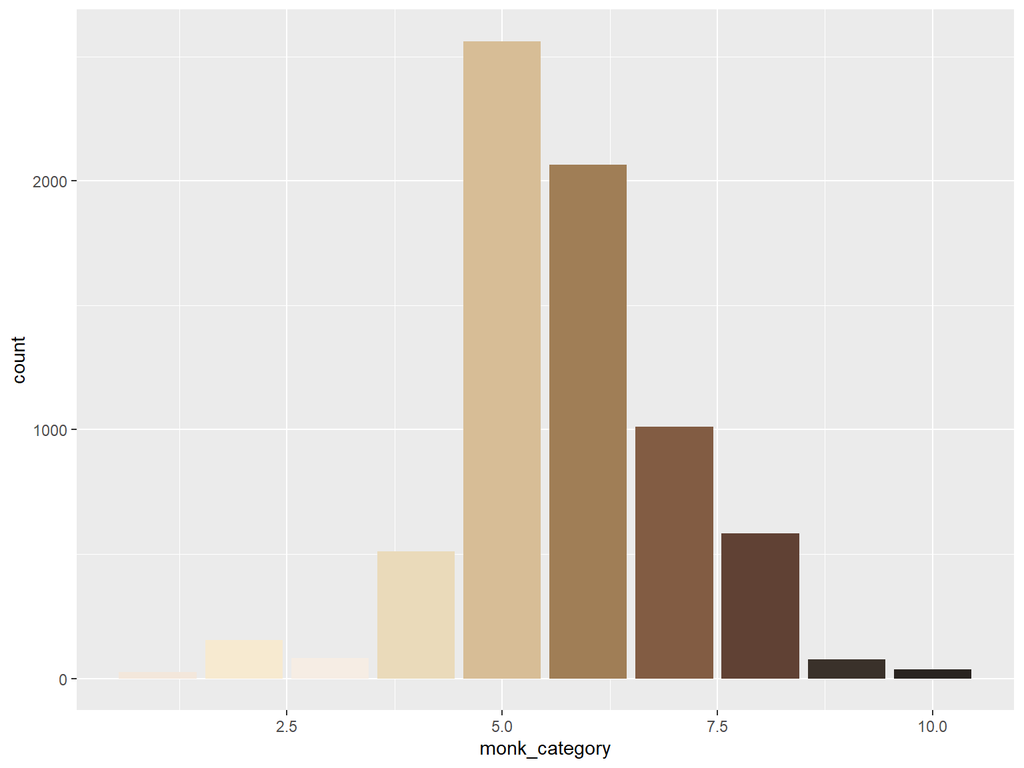

```r
shades <- shades %>%
  mutate(
    hex_color = case_when(
      monk_category == 1  ~ "#f6ede4",
      monk_category == 2  ~ "#f3e7db",
      monk_category == 3  ~ "#f7ead0",
      monk_category == 4  ~ "#eadaba",
      monk_category == 5  ~ "#d7bd96",
      monk_category == 6  ~ "#a07e56",
      monk_category == 7  ~ "#825c43",
      monk_category == 8  ~ "#604134",
      monk_category == 9  ~ "#3a312a",
      monk_category == 10 ~ "#292420"
    )
  )
monk_palette <- c(
  "#f6ede4", "#f3e7db", "#f7ead0", "#eadaba", "#d7bd96",
  "#a07e56", "#825c43", "#604134", "#3a312a", "#292420")

two <- shades %>% distinct(brand_name,shade_name,.keep_all = T)
two_counts <-shades %>%  distinct(brand_name,shade_name,.keep_all = T) %>% summarise(count=n(),.by=brand_name)
two %>% ggplot(aes(x=monk_category, fill=hex_color)) + geom_bar(show.legend = F) + scale_fill_manual(values = monk_palette[10:1])
```

```r
as_tibble(two_counts)
```

```
## # A tibble: 105 × 2
##    brand_name              count
##    <chr>                   <int>
##  1 About Face                 45
##  2 Ami Colé                   33
##  3 AMOREPACIFIC                5
##  4 Anastasia Beverly Hills   114
##  5 Armani Beauty             108
##  6 Au Naturale                30
##  7 bareMinerals              181
##  8 BASMA                      42
##  9 Beautyblender              60
## 10 BLK/OPL                    35
## # ℹ 95 more rows
```

## It’s Giving Twin: What similarities do the top 2 monk categories have with each other?

This was an interesting sidequest but doesn’t tell us much about options.

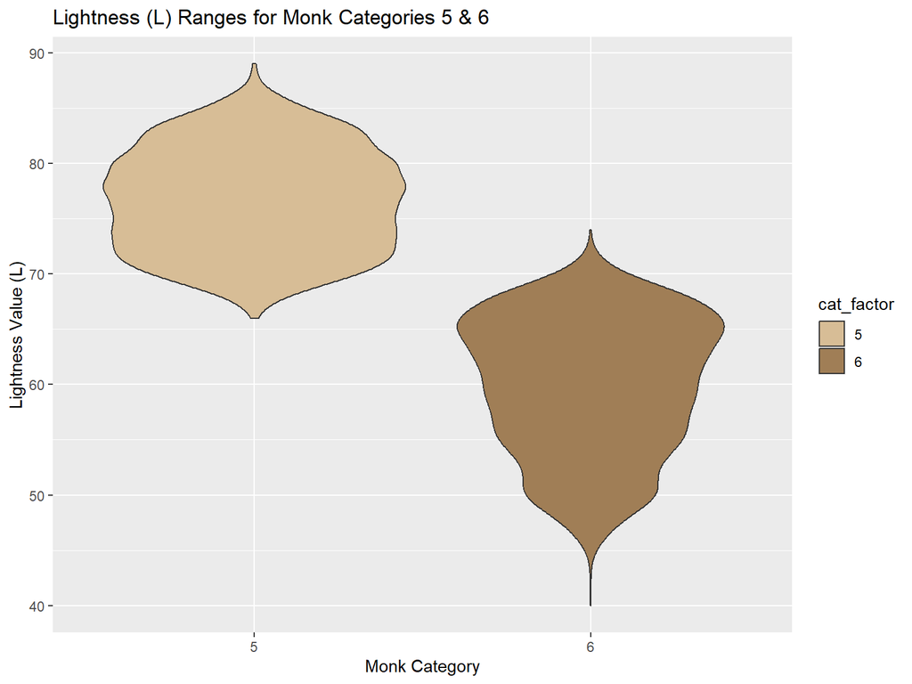

```r
shades %>%
  filter(monk_category %in% c(5, 6)) %>%
  distinct(brand_name, shade_name, .keep_all = TRUE) %>%
  mutate(cat_factor = factor(monk_category),
         L=round(L)) %>%filter(L < 200) %>% #filtering bc the highest possible lightness can be is 100
  ggplot(aes(x = cat_factor, y = L, fill = cat_factor)) + geom_violin() +
        scale_fill_manual(values = c(monk_palette[5], monk_palette[6])) +
        labs(title = "Lightness (L) Ranges for Monk Categories 5 & 6",
       x = "Monk Category",
       y = "Lightness Value (L)")
```

# Can we turn on the Lights?

## What is the distribution of lightness Values?

Overall, the most frequent lightness value seems to be around 75 with a smaller peak around 50. The lightness values are pretty high compared to the monk scores. I guess reducing such a large range of values into 10 hex categories can leave a little room for error. However, I would label this as most lightness values falling into a medium skintone range as 75 represents a 75% luminance.

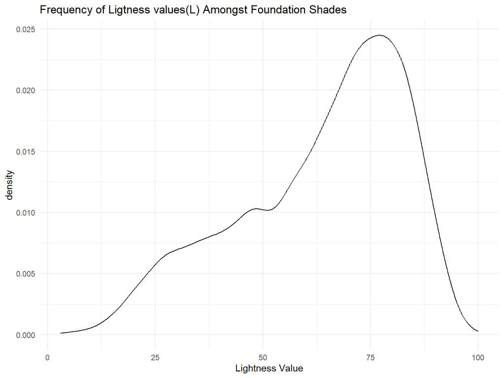

```r
shades %>% mutate(L=round(L)) %>%
        filter((L<200)) %>%
        ggplot(aes(L)) +
        geom_density() + labs(title = 'Frequency of Ligtness values(L) Amongst Foundation Shades',x='Lightness Value') + theme_minimal()
```

# Undertones and Skintones

## Watching your tone? What skin tone and undertone combination is most prevalent?

Deep Neutral is the most common skintone and undertone combination, light Neutral is only slightly behind.

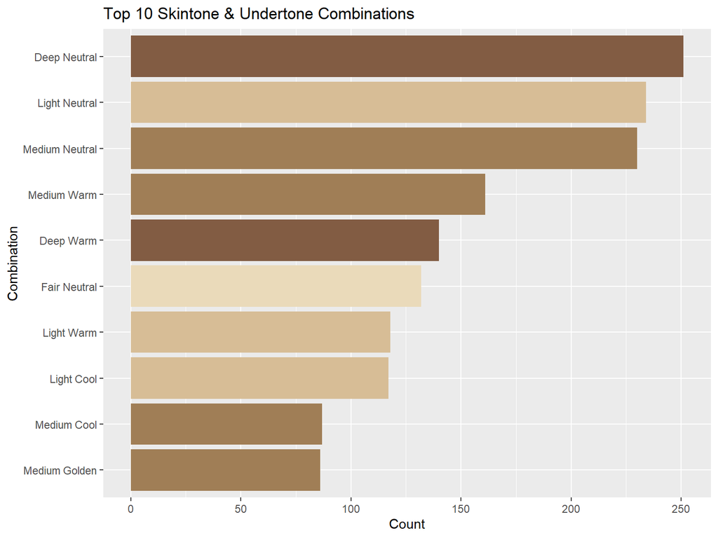

```r
skin_undertone <- shades %>%
  filter(!is.na(skintone), !is.na(undertone)) %>%
  summarise(count = n(),
            avg_monk = round(mean(monk_category, na.rm = TRUE)),
            .by = c(skintone, undertone)) %>%
        slice_max(count, n = 10) %>%
        mutate(combo_label = paste(skintone, undertone),
    fill_color = monk_palette[avg_monk]
  )

skin_undertone %>%  ggplot(aes(x = reorder(combo_label, count), y = count, fill =fill_color )) +
  geom_col() + coord_flip() + scale_fill_identity() +
  labs(title = "Top 10 Skintone & Undertone Combinations",
       x = "Combination",
       y = "Count")
```

```r
shades %>% mutate(skintone,undertone)
```

```
## # A tibble: 9,844 × 9
##    brand_name shade_name product_id name  skintone undertone monk_category     L
##    <chr>      <chr>           <dbl> <chr> <chr>    <chr>             <dbl> <dbl>
##  1 About Face L2OLIVE             1 <NA>  <NA>     <NA>                  4  89.7
##  2 About Face L2Neutral           1 <NA>  <NA>     Neutral               4  87.3
##  3 About Face L2PEACH             1 <NA>  <NA>     Peach                 5  84.0
##  4 About Face LM2OLIVE            1 <NA>  <NA>     <NA>                  5  84.3
##  5 About Face LM1COOL             1 <NA>  <NA>     Cool                  5  83.8
##  6 About Face LM1Warm             1 <NA>  Light M… Warm                  5  83.9
##  7 About Face LM2Neutral          1 <NA>  <NA>     Neutral               5  81.7
##  8 About Face LM2PEACH            1 <NA>  <NA>     Peach                 5  83.4
##  9 About Face LM1Neutral          1 <NA>  <NA>     Neutral               4  86.4
## 10 About Face L1COOL              1 <NA>  <NA>     Cool                  4  89.6
## # ℹ 9,834 more rows
## # ℹ 1 more variable: hex_color <chr>
```

Diving into Skin Tone I wanted to look at the distribution of skin tone labeling,

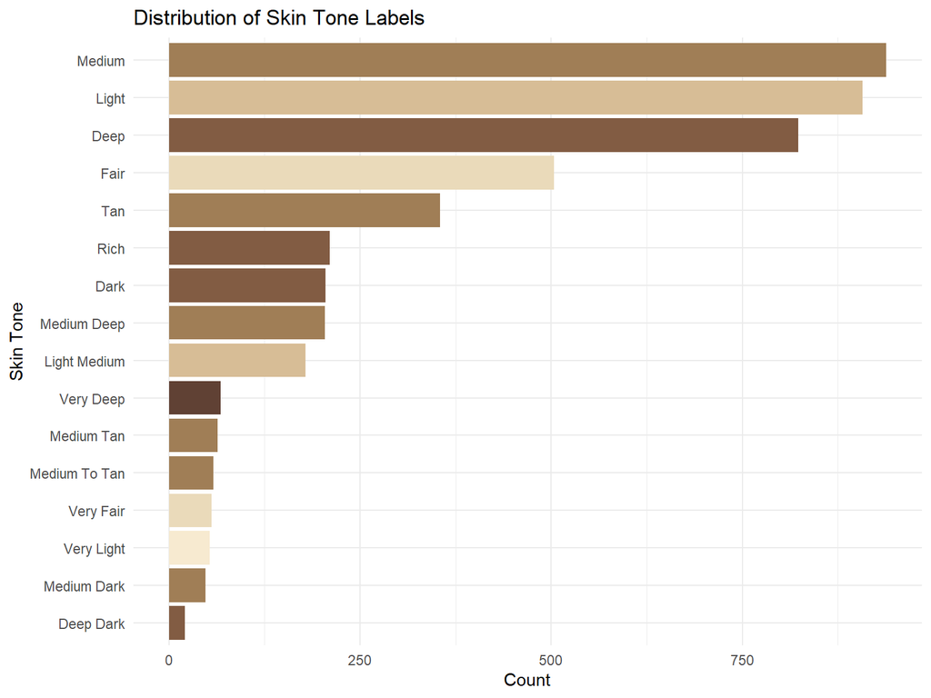

```r
skin_explore2 <- shades %>% filter(!is.na(skintone)) %>%
        summarise(count = n(), avg_monk = round(mean(monk_category)),
                  color=monk_palette[avg_monk],.by=skintone) %>%
        filter(count > 10 ) %>%
        ggplot(aes(reorder(x=skintone,count),count,fill=color))+
        geom_col()+ scale_fill_identity()+
        labs(title = 'Distribution of Skin Tone Labels', x='Skin Tone',y='Count') +
        coord_flip() + theme_minimal()


skin_explore2
```

# What Undertones offer the most options in monk range

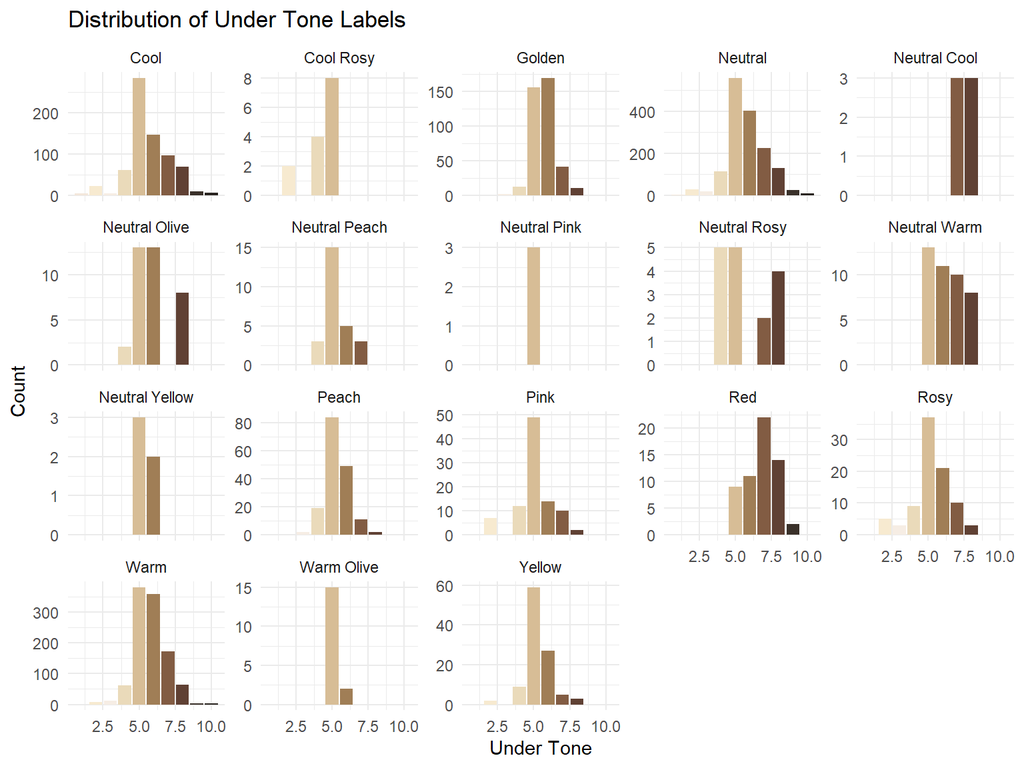

```r
shades %>% mutate(L=round(L)) %>% filter(!is.na(undertone)) %>%
  group_by(undertone,monk_category,hex_color) %>%
  summarise(count = n())%>% filter(count > 1) %>%
  ggplot(aes(x=monk_category,count,fill=hex_color))+
  geom_col(show.legend = F) + facet_wrap(~undertone,scales='free_y')+
  labs(title = 'Distribution of Under Tone Labels', x='Under Tone',y='Count') +scale_fill_manual(values = monk_palette[10:1]) + theme_minimal()
```

# But is it Tracking?

### How Do Various Brand Types Compare to the Overall Population?

To get a better idea of how shade range and tones were distributed, I decided to make 3 categories of Brands.

```r
luxury_brands <- 'Armani Beauty,|DIOR|Hourglass|NATASHA DENONA|PAT McGRATH LABS'
lux_shades<- shades %>% filter(str_detect(brand_name,luxury_brands)) %>% mutate(category = "Luxury")

pop_brands <- 'Danessa Myricks Beauty|HAUS LABS BY LADY GAGA|MAKEUP BY MARIO|Rare Beauty by Selena Gomez|Huda Beauty'
pop_shades<- shades %>% filter(str_detect(brand_name,pop_brands)) %>% mutate(category = "Trendy")

afford_brands <-'e.l.f. Cosmetics|Revlon|NYX Professional Makeup|Maybelline|SEPHORA COLLECTION'
top_shades<- shades %>% filter(str_detect(brand_name, afford_brands)) %>% mutate(category = "Affordable")

categorized_brands <- bind_rows(lux_shades, pop_shades, top_shades)
```

Across the 3 categories I looked into all brands seem to have the most shades in the same lightness range. Luxury brands seem to concentrate most of their foundation brands to a higher lightness with little identifiable peaks in lower lightness ranges. However Trendy brands have visible peaking in lower lightness ranges suggesting more foundation products available in lower ranges.

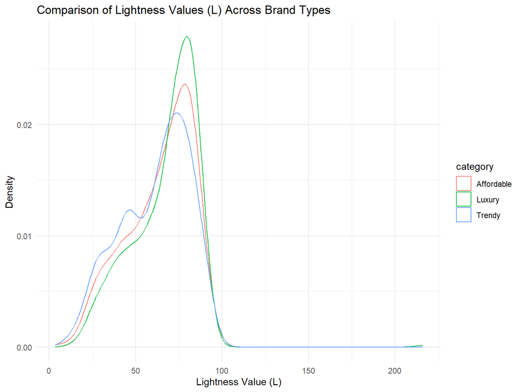

```r
#lux_shades %>% ggplot(aes(L)) + geom_density() + labs(title = 'Frequency of Ligtness values(L) in Luxury Brand Foundation Shades ',
                                                       #x='Lightness Value') + theme_minimal()
#pop_shades %>% ggplot(aes(L)) + geom_density() + labs(title = 'Frequency of Ligtness values(L) in Trendy Brand Foundation Shades ',
                                                       #x='Lightness Value')+ theme_minimal()
#top_shades %>% ggplot(aes(L)) + geom_density() + labs(title = 'Frequency of Ligtness values(L) in Affordable Brand Foundation Shades ',
                                                       #x='Lightness Value') + theme_minimal()

ggplot(categorized_brands, aes(x = L, color = category)) +
  geom_density(alpha = 0.4) + # 'alpha' makes it transparent so you can see overlaps
  labs(title = "Comparison of Lightness Values (L) Across Brand Types",
       x = "Lightness Value (L)",
       y = "Density",
       fill = "Brand Type") +theme_minimal()
```

# A Range of Options:

## What Brand Categories offer the most Variety?

When looking at the frequency by of undertones one thing is very clear Neutral is by far the most used undertone description. This aligns with the combination of deep neutral being the #1 used skintone/undertone combination.

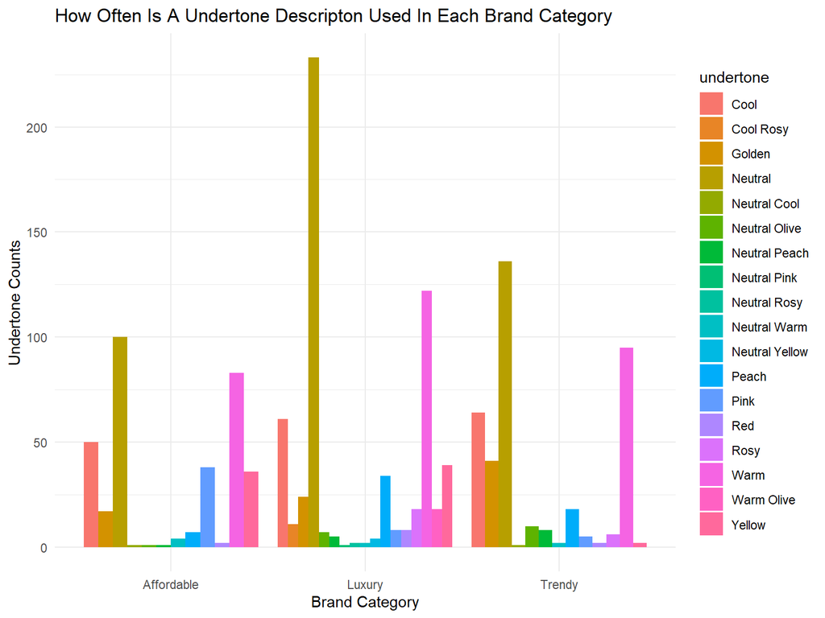

```r
categorized_brands %>% filter(!is.na(undertone)) %>% group_by(category) %>%
 ggplot(aes(category,fill=undertone))+geom_bar(position = 'dodge') + theme_minimal() +
labs(title = str_to_title('How often is a Undertone descripton used in each brand category'),x='Brand Category',y='Undertone Counts')
```

```r
print(categorized_brands %>% filter(!is.na(undertone)) %>% summarise(n(),.by=(category)))
```

```
## # A tibble: 3 × 2
##   category   `n()`
##   <chr>      <int>
## 1 Luxury       597
## 2 Trendy       390
## 3 Affordable   340
```

## Skintone Vs Brand Category

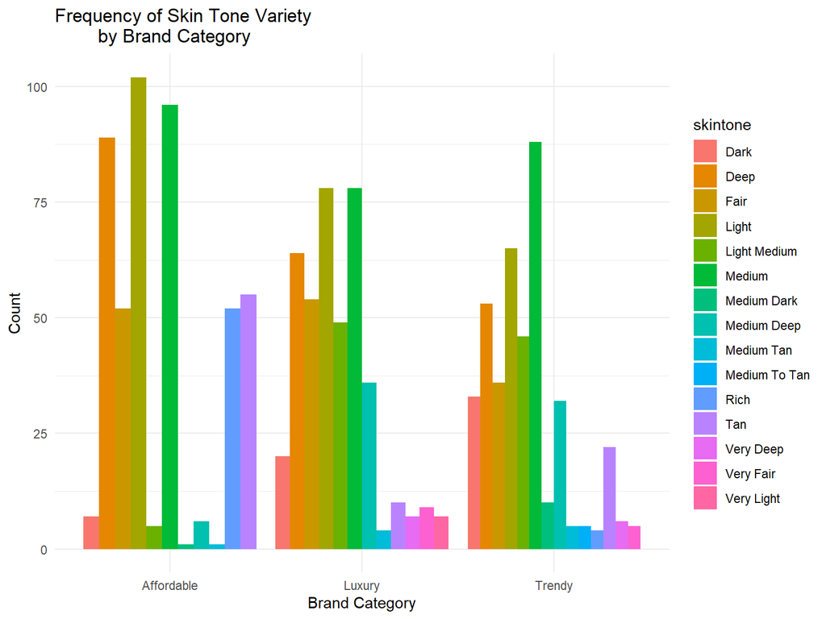

```r
categorized_brands %>% filter(!is.na(skintone)) %>%group_by(category) %>%
        ggplot(aes(category,fill=skintone))+geom_bar(position = 'dodge') + labs(title = "Frequency of Skin Tone Variety
        by Brand Category",y="Count",x='Brand Category' ) + theme_minimal()
```

```r
print(categorized_brands %>% filter(!is.na(skintone)) %>% summarise(n(),.by = category))
```

```
## # A tibble: 3 × 2
##   category   `n()`
##   <chr>      <int>
## 1 Luxury       416
## 2 Trendy       410
## 3 Affordable   466
```

So my suspicions were correct! Although Deep is the third largest skintone shade offered, neutral is the top undertone offered in the category.

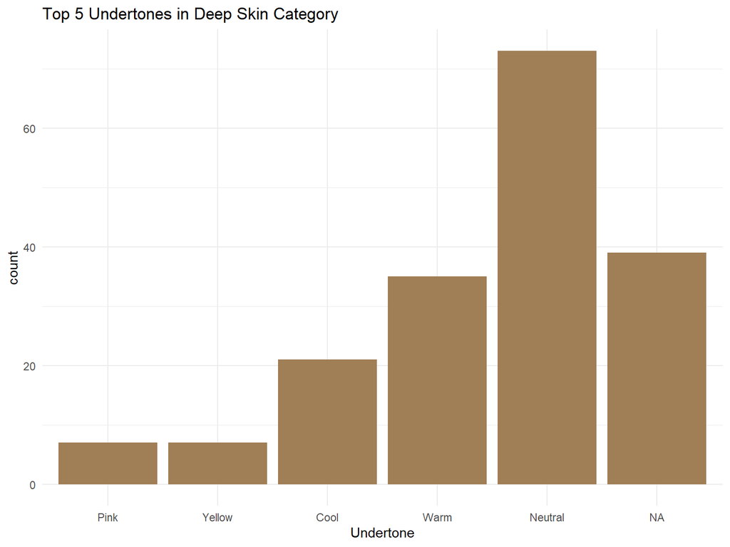

```r
categorized_brands %>% filter(skintone =='Deep') %>% summarise(count = n(),.by = undertone) %>%
        top_n(5) %>% ggplot(aes(reorder(x=undertone,count),count)) + geom_col(fill='#a07e56') + labs(title = 'Top 5 Undertones in Deep Skin Category',x ='Undertone') + theme_minimal()
```

### Brand Category Vs Monk Category

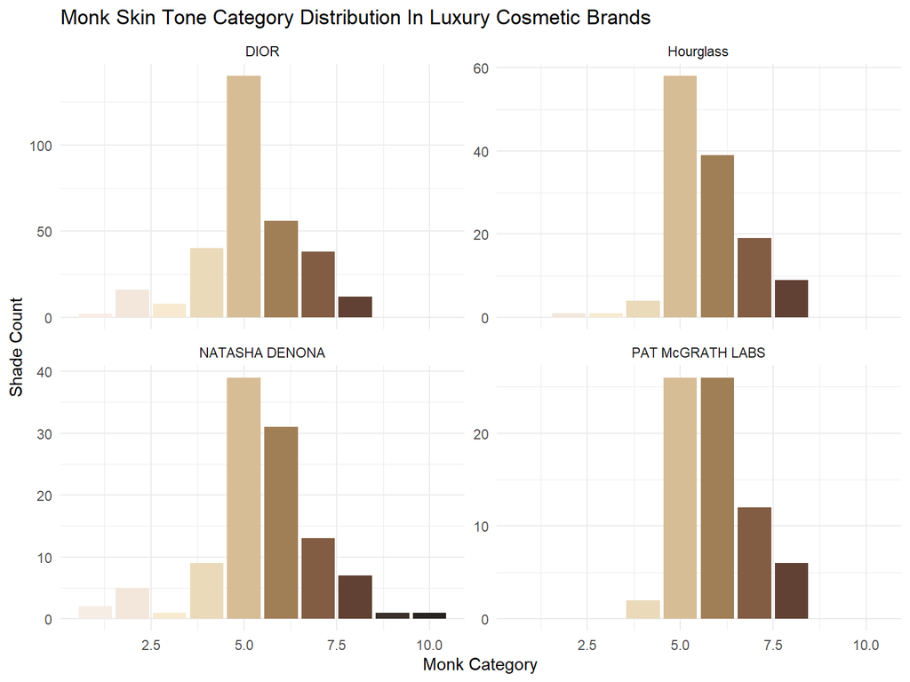

```r
ls1<-lux_shades %>% ggplot(aes(x = monk_category, fill = hex_color)) +
  geom_bar() +
  facet_wrap(~ brand_name, scales = "free_y") +
  scale_fill_identity() +
  labs(
    title = "Monk Skin Tone Category Distribution In Luxury Cosmetic Brands",
    x = "Monk Category",
    y = "Shade Count"
  )+theme_minimal()
ps1<- pop_shades %>% ggplot(aes(x = monk_category, fill = hex_color)) +
  geom_bar() +
  facet_wrap(~ brand_name, scales = "free_y") +
  scale_fill_identity() +
  labs(
    title = "Monk Skin Tone Category Distribution In Trending Cosmetic Brands",
    x = "Monk Category",
    y = "Shade Count"
  )+theme_minimal()
ts1<-top_shades %>% ggplot(aes(x = monk_category, fill = hex_color)) +
  geom_bar() +
  facet_wrap(~ brand_name, scales = "free_y") +
  scale_fill_identity() +
  labs(
    title = "Monk Skin Tone Category Distribution In Affordable Cosmetic Brands",
    x = "Monk Category",
    y = "Shade Count"
  )+theme_minimal()
ls1
```

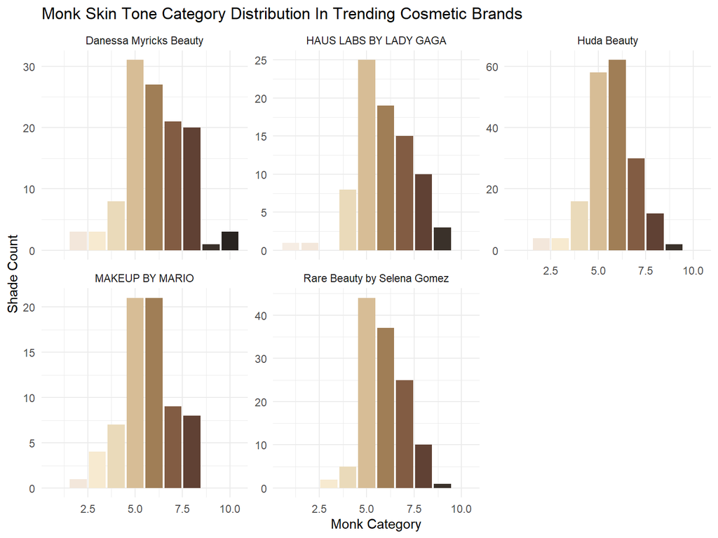

```r
ps1
```

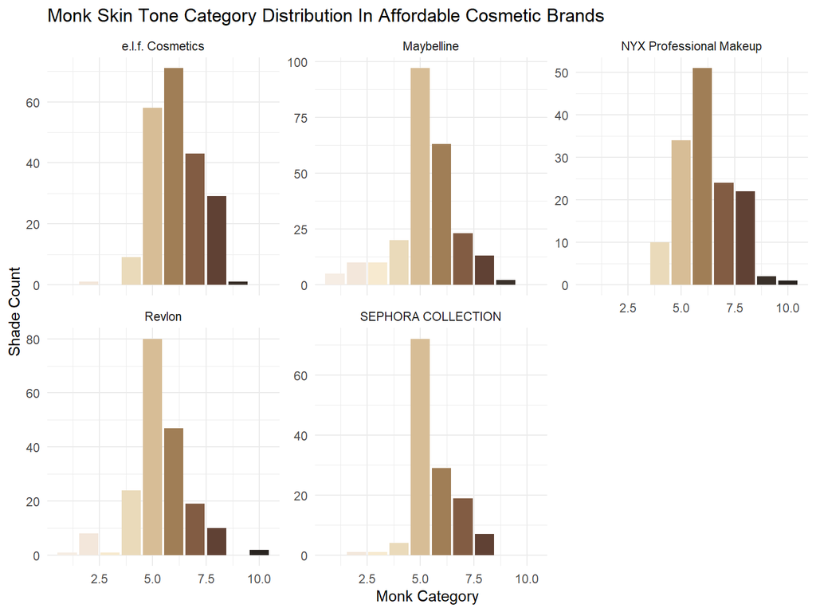

```r
ts1
```

# Conclusion:

When looking based on categories the affordable brands offered the most in terms of range of skin tone while luxury brands exceeded in undertone distribution.Affordable products have a happy medium that tends to lean towards darker and medium shades. Popular Brands lean towards offering wider ranges and more products in darker shades compared to luxury and affordable brands.

Overall the skintone most offered is medium, the most common monk range is 5.0. Shdaes on the palest and darkest sides of the spectrum tend to have the least offerings overall.